Explore and Summarize Data (Red Wine Quality Data Exploration) ______________________________________________________________ The purpose of this project was to do preliminary exploration of wine data, with a goal of selecting right attributes for classifying wine into one of the quality categories: poor, normal and excellent. Since the data was already in tidy structure, not much attention was payed in data wrangling, but finding relationships among the attributes and between attributes and the wine quality. The wine quality dataset was created by Paulo Cortez (Univ. Minho), Antonio Cerdeira, Fernando Almeida, Telmo Matos and Jose Reis (CVRVV) @ 2009, using red wine samples. The inputs include objective tests (e.g. PH values) and the output is based on sensory data (median of at least 3 evaluations made by wine experts). Each expert graded the wine quality between 0 (very bad) and 10 (very excellent).

```
##  [1] "X"                    "fixed.acidity"        "volatile.acidity"
##  [4] "citric.acid"          "residual.sugar"       "chlorides"
##  [7] "free.sulfur.dioxide"  "total.sulfur.dioxide" "density"
## [10] "pH"                   "sulphates"            "alcohol"
## [13] "quality"
```

```
## 'data.frame':    1599 obs. of  13 variables:
##  $ X                   : int  1 2 3 4 5 6 7 8 9 10 ...
##  $ fixed.acidity       : num  7.4 7.8 7.8 11.2 7.4 7.4 7.9 7.3 7.8 7.5 ...
##  $ volatile.acidity    : num  0.7 0.88 0.76 0.28 0.7 0.66 0.6 0.65 0.58 0.5 ...
##  $ citric.acid         : num  0 0 0.04 0.56 0 0 0.06 0 0.02 0.36 ...
##  $ residual.sugar      : num  1.9 2.6 2.3 1.9 1.9 1.8 1.6 1.2 2 6.1 ...
##  $ chlorides           : num  0.076 0.098 0.092 0.075 0.076 0.075 0.069 0.065 0.073 0.071 ...
##  $ free.sulfur.dioxide : num  11 25 15 17 11 13 15 15 9 17 ...
##  $ total.sulfur.dioxide: num  34 67 54 60 34 40 59 21 18 102 ...
##  $ density             : num  0.998 0.997 0.997 0.998 0.998 ...
##  $ pH                  : num  3.51 3.2 3.26 3.16 3.51 3.51 3.3 3.39 3.36 3.35 ...
##  $ sulphates           : num  0.56 0.68 0.65 0.58 0.56 0.56 0.46 0.47 0.57 0.8 ...
##  $ alcohol             : num  9.4 9.8 9.8 9.8 9.4 9.4 9.4 10 9.5 10.5 ...
##  $ quality             : int  5 5 5 6 5 5 5 7 7 5 ...
```

```
##        X          fixed.acidity   volatile.acidity  citric.acid
##  Min.   :   1.0   Min.   : 4.60   Min.   :0.1200   Min.   :0.000
##  1st Qu.: 400.5   1st Qu.: 7.10   1st Qu.:0.3900   1st Qu.:0.090
##  Median : 800.0   Median : 7.90   Median :0.5200   Median :0.260
##  Mean   : 800.0   Mean   : 8.32   Mean   :0.5278   Mean   :0.271
##  3rd Qu.:1199.5   3rd Qu.: 9.20   3rd Qu.:0.6400   3rd Qu.:0.420
##  Max.   :1599.0   Max.   :15.90   Max.   :1.5800   Max.   :1.000
##  residual.sugar     chlorides       free.sulfur.dioxide
##  Min.   : 0.900   Min.   :0.01200   Min.   : 1.00
##  1st Qu.: 1.900   1st Qu.:0.07000   1st Qu.: 7.00
##  Median : 2.200   Median :0.07900   Median :14.00
##  Mean   : 2.539   Mean   :0.08747   Mean   :15.87
##  3rd Qu.: 2.600   3rd Qu.:0.09000   3rd Qu.:21.00
##  Max.   :15.500   Max.   :0.61100   Max.   :72.00
##  total.sulfur.dioxide    density             pH          sulphates
##  Min.   :  6.00       Min.   :0.9901   Min.   :2.740   Min.   :0.3300
##  1st Qu.: 22.00       1st Qu.:0.9956   1st Qu.:3.210   1st Qu.:0.5500
##  Median : 38.00       Median :0.9968   Median :3.310   Median :0.6200
##  Mean   : 46.47       Mean   :0.9967   Mean   :3.311   Mean   :0.6581
##  3rd Qu.: 62.00       3rd Qu.:0.9978   3rd Qu.:3.400   3rd Qu.:0.7300
##  Max.   :289.00       Max.   :1.0037   Max.   :4.010   Max.   :2.0000
##     alcohol         quality
##  Min.   : 8.40   Min.   :3.000
##  1st Qu.: 9.50   1st Qu.:5.000
##  Median :10.20   Median :6.000
##  Mean   :10.42   Mean   :5.636
##  3rd Qu.:11.10   3rd Qu.:6.000
##  Max.   :14.90   Max.   :8.000
```

# Univariate Plots Section

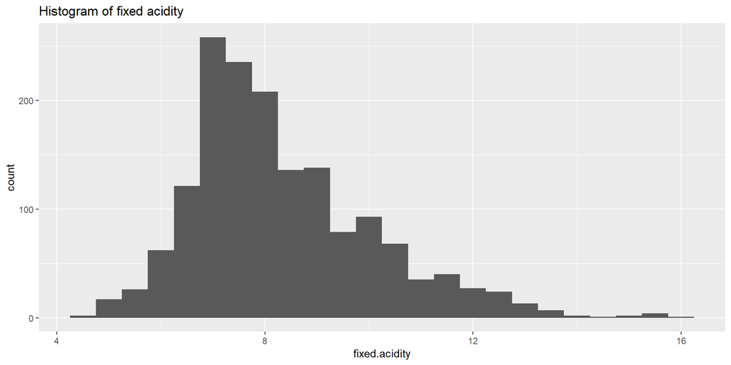

```
##    Min. 1st Qu.  Median    Mean 3rd Qu.    Max.
##    4.60    7.10    7.90    8.32    9.20   15.90
```

```
## [1] 1599   12
```

```
##  [1] "fixed.acidity"        "volatile.acidity"     "citric.acid"
##  [4] "residual.sugar"       "chlorides"            "free.sulfur.dioxide"
##  [7] "total.sulfur.dioxide" "density"              "pH"
## [10] "sulphates"            "alcohol"              "quality"
```

```
##  fixed.acidity   volatile.acidity  citric.acid    residual.sugar
##  Min.   : 4.60   Min.   :0.1200   Min.   :0.000   Min.   : 0.900
##  1st Qu.: 7.10   1st Qu.:0.3900   1st Qu.:0.090   1st Qu.: 1.900
##  Median : 7.90   Median :0.5200   Median :0.260   Median : 2.200
##  Mean   : 8.32   Mean   :0.5278   Mean   :0.271   Mean   : 2.539
##  3rd Qu.: 9.20   3rd Qu.:0.6400   3rd Qu.:0.420   3rd Qu.: 2.600
##  Max.   :15.90   Max.   :1.5800   Max.   :1.000   Max.   :15.500
##    chlorides       free.sulfur.dioxide total.sulfur.dioxide
##  Min.   :0.01200   Min.   : 1.00       Min.   :  6.00
##  1st Qu.:0.07000   1st Qu.: 7.00       1st Qu.: 22.00
##  Median :0.07900   Median :14.00       Median : 38.00
##  Mean   :0.08747   Mean   :15.87       Mean   : 46.47
##  3rd Qu.:0.09000   3rd Qu.:21.00       3rd Qu.: 62.00
##  Max.   :0.61100   Max.   :72.00       Max.   :289.00
##     density             pH          sulphates         alcohol
##  Min.   :0.9901   Min.   :2.740   Min.   :0.3300   Min.   : 8.40
##  1st Qu.:0.9956   1st Qu.:3.210   1st Qu.:0.5500   1st Qu.: 9.50
##  Median :0.9968   Median :3.310   Median :0.6200   Median :10.20
##  Mean   :0.9967   Mean   :3.311   Mean   :0.6581   Mean   :10.42
##  3rd Qu.:0.9978   3rd Qu.:3.400   3rd Qu.:0.7300   3rd Qu.:11.10
##  Max.   :1.0037   Max.   :4.010   Max.   :2.0000   Max.   :14.90
##     quality
##  Min.   :3.000
##  1st Qu.:5.000
##  Median :6.000
##  Mean   :5.636
##  3rd Qu.:6.000
##  Max.   :8.000
```

By creating histogram plots is a good way to have an idea about how each attributes are changing by themselves. The plots will help me to know all features at the first view.

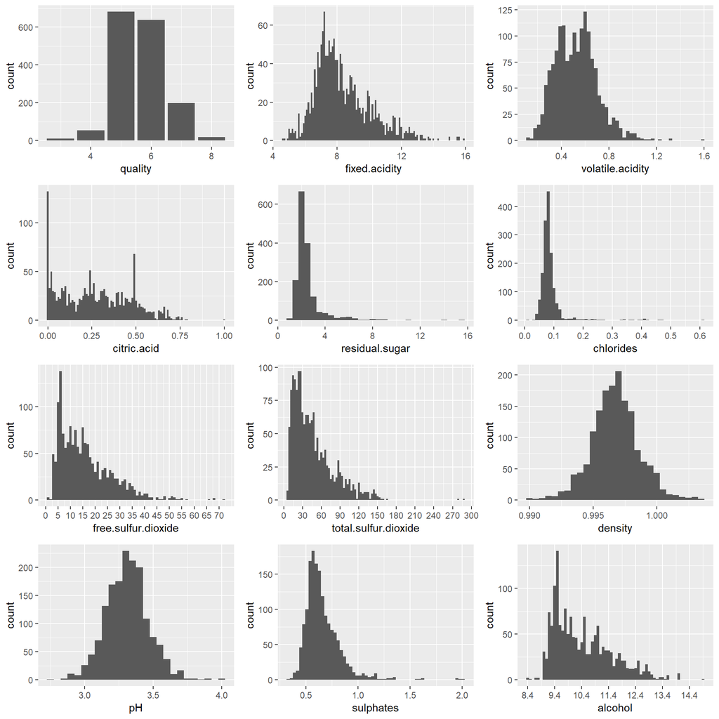

Many of the variables look normally distributed. Chlorides, sulphates, alcohol, free sulfur dioxide and total sulfur dioxide look like they have lognormal distributions. Letâs exclude the 95th percentile for all these five features and re-plot their histograms:

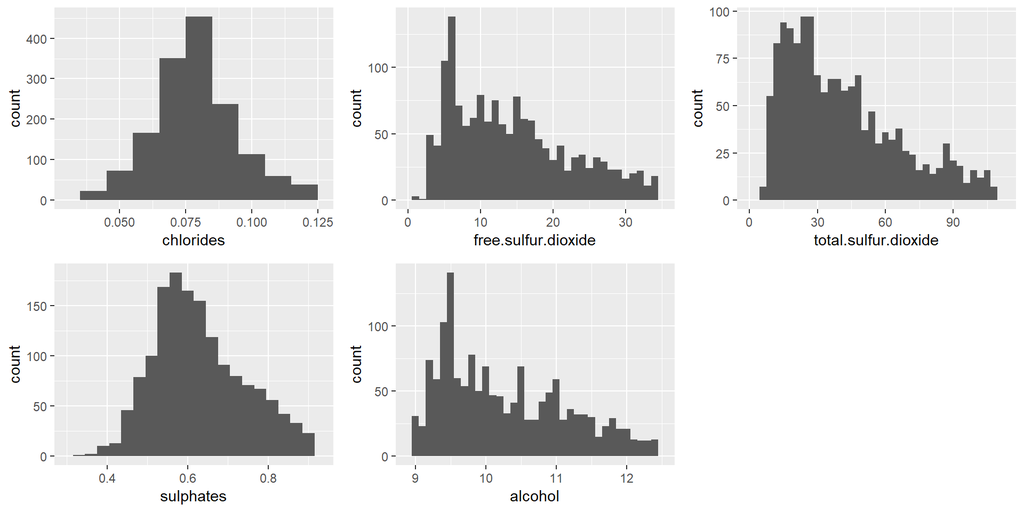

# Univariate Analysis

### What is the structure of your dataset?

The Number of red wine instances: 1599 The Number of Attributes: 1 Serial Number + 11 Attributes + 1 Output Attribute

The 11 Attributes are 1 - fixed acidity: most acids involved with wine or fixed or nonvolatile (do not evaporate readily) 2 - volatile acidity: the amount of acetic acid in wine, which at too high of levels can lead to an unpleasant, vinegar taste 3 - citric acid: found in small quantities, citric acid can add ‘freshness’ and flavor to wines 4 - residual sugar: the amount of sugar remaining after fermentation stops, it’s rare to find wines with less than 1 gram/liter and wines with greater than 45 grams/liter are considered sweet 5 - chlorides: the amount of salt in the wine 6 - free sulfur dioxide: the free form of SO2 exists in equilibrium between molecular SO2 (as a dissolved gas) and bisulfite ion; it prevents microbial growth and the oxidation of wine 7 - total sulfur dioxide: amount of free and bound forms of S02; in low concentrations, SO2 is mostly undetectable in wine, but at free SO2 concentrations over 50 ppm, SO2 becomes evident in the nose and taste of wine 8 - density: the density of water is close to that of water depending on the percent alcohol and sugar content 9 - pH: describes how acidic or basic a wine is on a scale from 0 (very acidic) to 14 (very basic); most wines are between 3-4 on the pH scale 10 - sulphates: a wine additive which can contribute to sulfur dioxide gas (S02) levels, wich acts as an antimicrobial and antioxidant 11 - alcohol: the percent alcohol content of the wine Output variable (based on sensory data): 12 - quality (score between 0 and 10)

### What is/are the main feature(s) of interest in your dataset?

Quality is the main feature.

### What other features in the dataset do you think will help support your investigation into your feature(s) of interest?

Residual sugar, fixed acidity, pH, density and alcohol content may help support the investigation into the quality.

### Did you create any new variables from existing variables in the dataset?

Yes, I do. Since the first column is all serial numbers, there is not any statistical significance. The column, named X, has been remmoved from the original dataset.

# Bivariate Plots Section

```
##  [1] "fixed.acidity"        "volatile.acidity"     "citric.acid"
##  [4] "residual.sugar"       "chlorides"            "free.sulfur.dioxide"
##  [7] "total.sulfur.dioxide" "density"              "pH"
## [10] "sulphates"            "alcohol"              "quality"
```

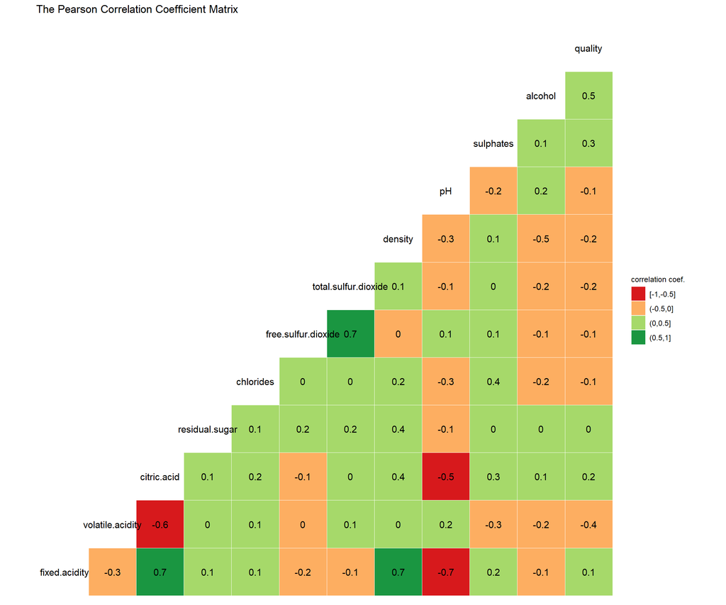

With our main feature of the dataset, the positive correlation coefficients which are more then 0.1 are:

```
 alchol:quality = 0.5
 sulphates:quality = 0.3
 citric.acid:quality = 0.2
 fixed.acidity:quality = 0.1
```

So alcohol content has a high correlation with red wine quality. Other important attributes correlated with red wine quality include sulphates, citric acid and fixed acidity.

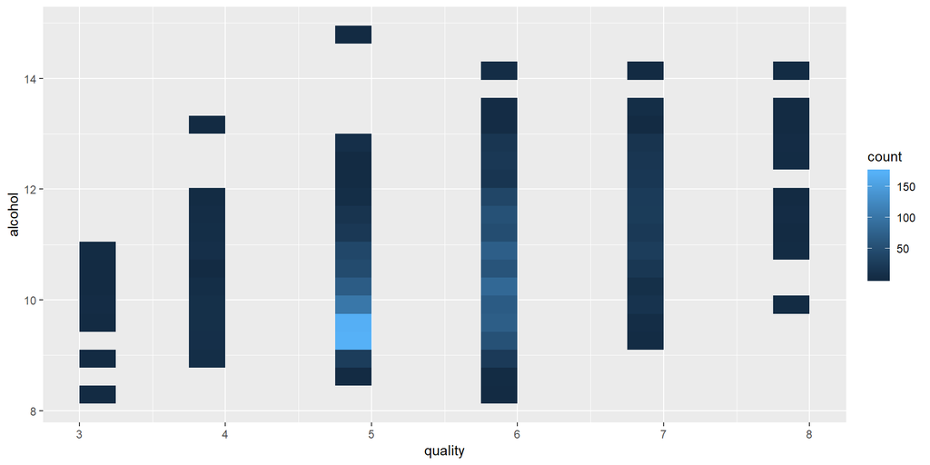

As we can see, from above plot with alcohol contect across quality, there is a large amount of samples with quality score 5 and also 9.5% alcohol. The samples with a higher quality score also have a higher alcohol percentage.

With our main feature of the dataset, the negative correlation coefficients which are less then -0.1 are:

```
 volatile.acidity:quality = -0.4
 total.sulfur.dioxide:quality = -0.2
 density:quality = -0.2
 chlorides:quality = -0.1
```

So we see that volatile acids are negatively correlated with red wine quality, as described from the document that is at too high of levels can lead to an unpleasant, vinegar taste. Total sulfur dioxide, density and chlorides are also negatively correlated with quality.

Besides, other attributes wiht the highest (positive or negative) correlation are:

```
 fixed.acidity:pH = -0.7
 fixed.acidity:citric.acid = 0.7
 fixed.acidity:density = 0.7
 free.sulfur.dioxide:total.sulfur.dioxide = 0.7
 volatile.acidity:citirc.acid = -0.6
 citric.acid:pH = -0.5
 density:alcohol = -0.5
```

#### pH Attribute

As we all know, the stronger the acid is, the lower pH will be. So it is make sence that either fixed acidity or citric acid has a high negative correlation with pH.

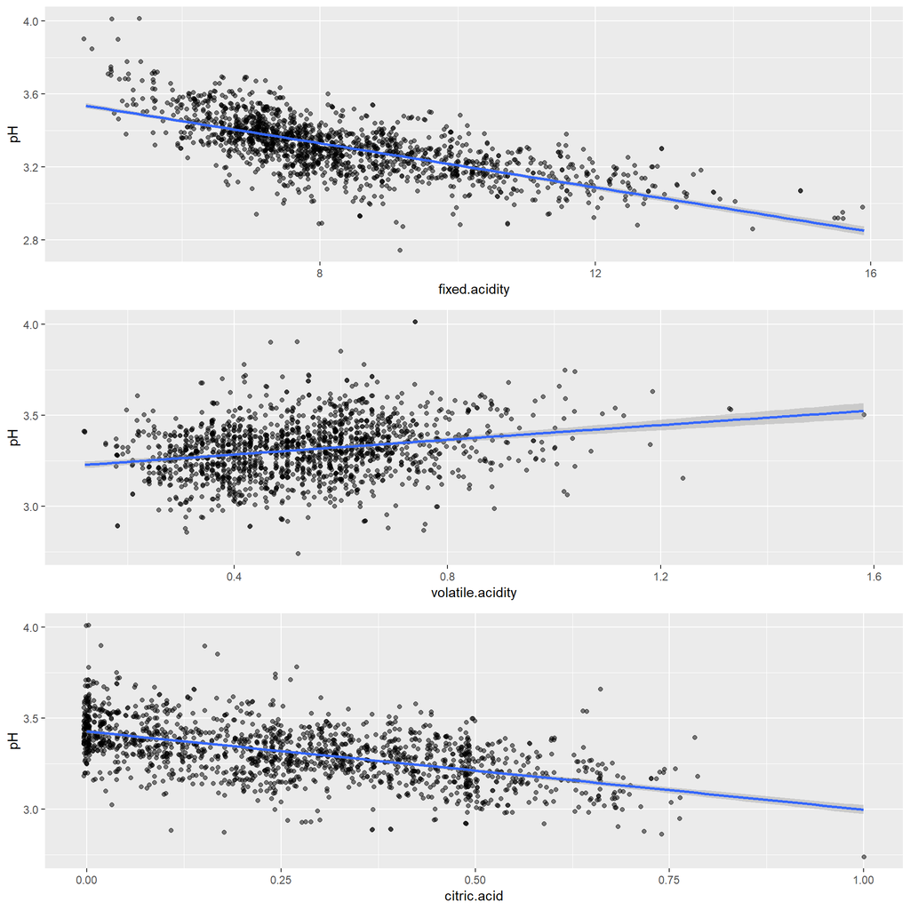

All three features are acids. I’ve thought all acids will lower the value of pH. However, from above plot of pH across volatile acidity, with more content of volatile acidity, the value of pH increase a little bit. From this set of plots, I found the acidity of volatile is weaker than the other two acids, and fixed acid should be the strongest one here.

I will focus on several other highest correlation relationships in a bit more detail.

### Acid Attributes

Wine Acids play a large role in winemaking. Each acid plays a different role in the winemaking game. I would like to see how three kinds of acids working with the quality of red wine.

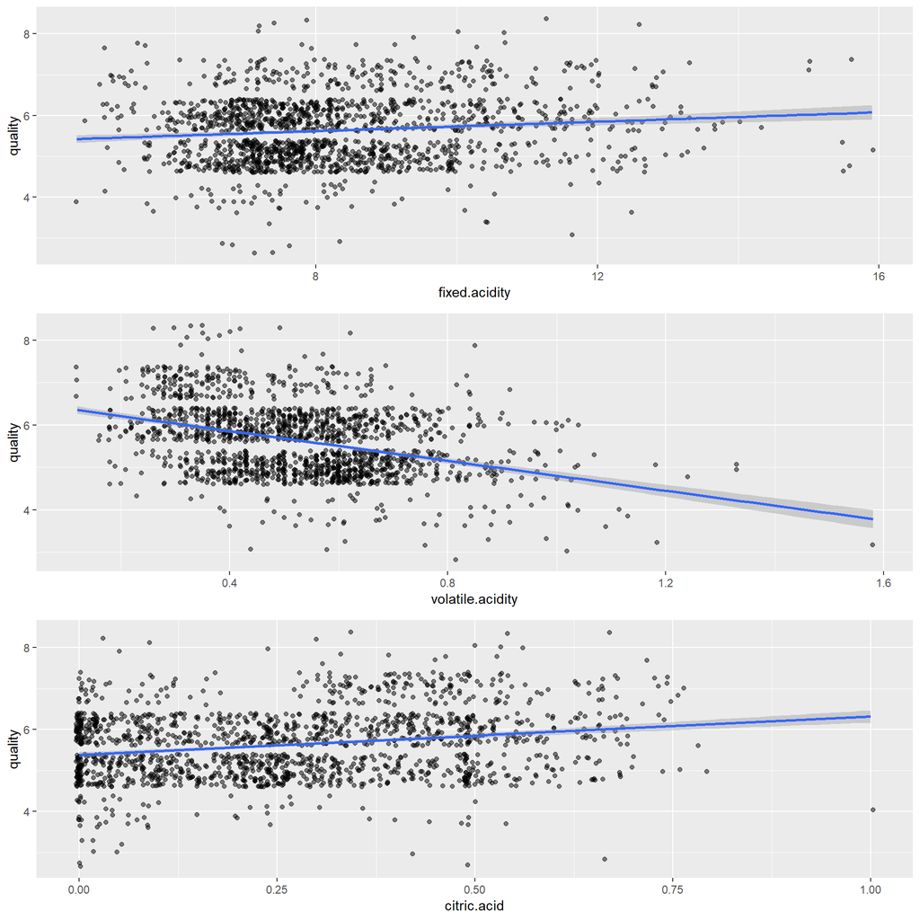

### Density Attribute

The density of wine somehow descides the taste of thick or refreshing. The description of density says the density of wine is close to that of water depending on the percent alcohol and sugar content. I would like to find out how alcohol and sugar content affact density, and also how density would work with the quality.

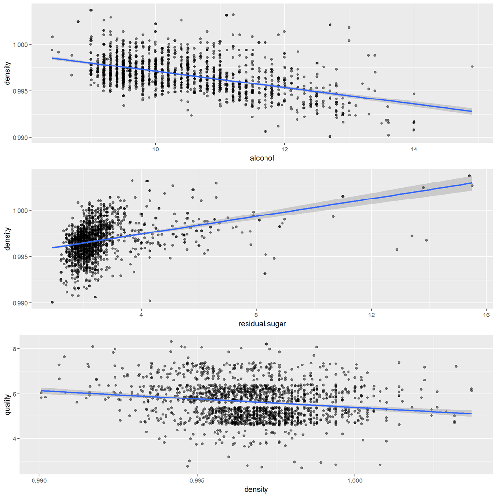

Obviously, the density of wine has been affacted a lot by alcohol and residual sugar. The wine would be more refreshing while having more alcohol, however would be thicker if adding more sugar content. Well, the wine sometimes has too much acidity, but winemakers don’t want to remove the volatile acid, they balance with sugar. The acids could be balanced off with residual sugar. Adding residual sugar might balance the taste of the wine. As we can see from the plot of quality with density, the quality is decreasing while the wine become thicker.

### How Volatile Acidity Affact Wine Quality

As of the feature of volatile acidity has a large negative pearson correlation coefficient. I would like to see more detail of how volatile acidity working with wine quality.

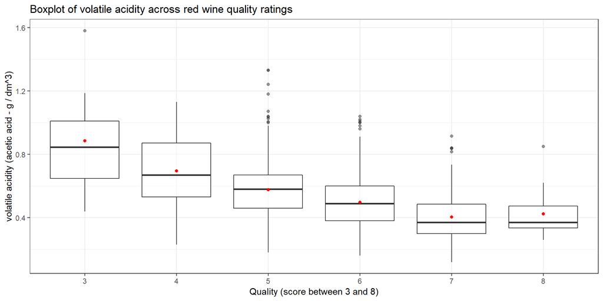

Based on the above boxplot, it is really easy to tell the observed result. High value of volatile acidity is truly lower the score of wine quality.

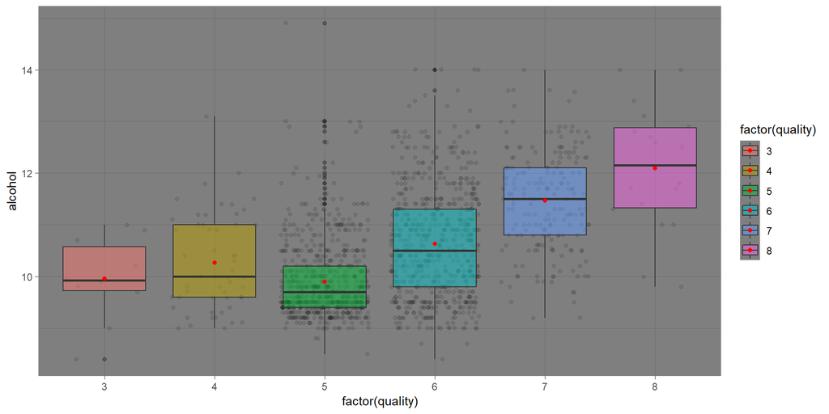

At the end of bbivariate analysis, I would like to re-focus on the main feature of dataset, which is quality. This boxplot is also showing one of the strongest relationship between quality and alcohol.

# Bivariate Analysis

### Talk about some of the relationships you observed in this part of the investigation. How did the feature(s) of interest vary with other features in the dataset?

As of the quality, it appears that when alchol or sulphates is in higher amounts, the quality will be better also. However, the amount of volatile acidity is negatively correlated with the quality. It is likely that fresher wines avoid the bitter taste of acetic acid.

### Did you observe any interesting relationships between the other features (not the main feature(s) of interest)?

As of citric acid, fixed acidity is positively correlated with the citric acid, but the amount of volatile acidity is opposite. As of density, fixed acidity is also positively correlated with the citric acid, but the amount of alcohol is opposite.

# Multivariate Plots Section

Now letâs visualize the relationship between density, volatile.acidity, alcohol and quality:

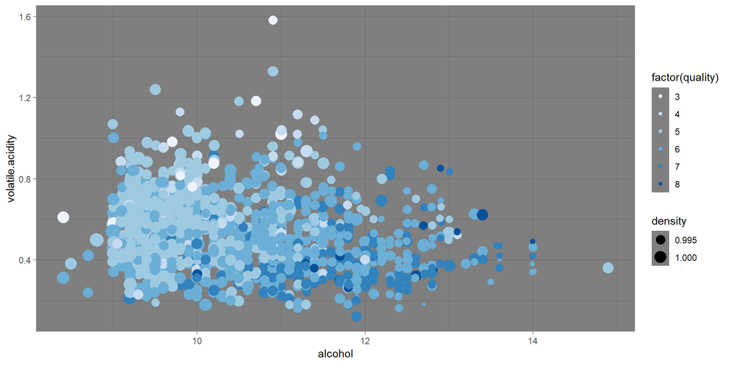

On the above scatter plot, the darker the blue is means the wine with higher quality. In other words, white points are with the lowest quality, and darkest blue points are with the highest quality. Besides, the most of white points are shown on the up-left part of canvas, and the bottom right corner has more blue or dark blue points. It means that most of the wine with higher quality scores have higher alcohol content and also lower volatile acidity.

Below faceted plots tried to see how sulphates or alcohol affacts the quality of wine

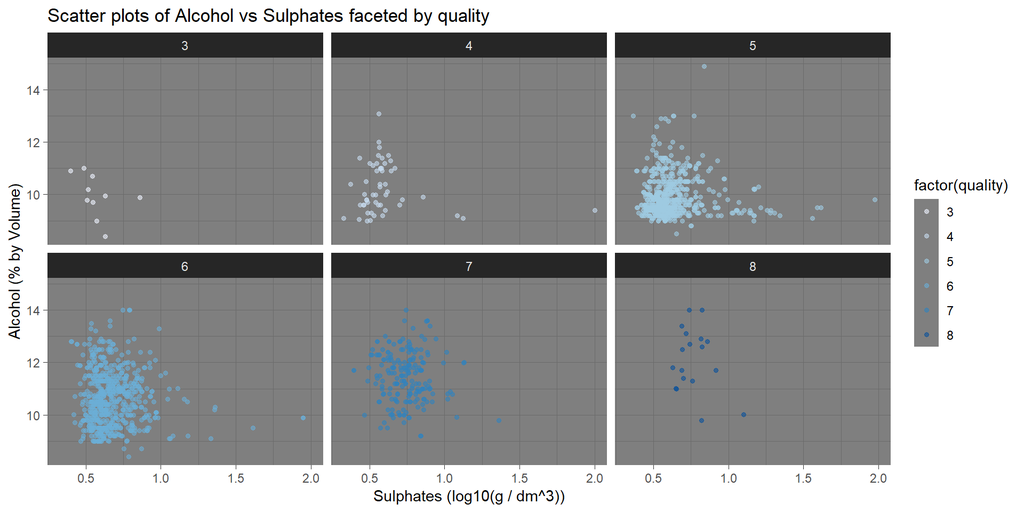

Interesting, sulphates also slightly affact the quality of wine. From above six plots, all scatter points are slightly moving to right. We almost cannot realize between two contiguous plots. But while we compare the first one with the fifth or sixth one, it actually shift a step to right. It comes out that sulphates help a little bit to increase the score of wine quality.

Next, letâs try to summarize quality using a contour plot of volatile acidity and sulphate content:

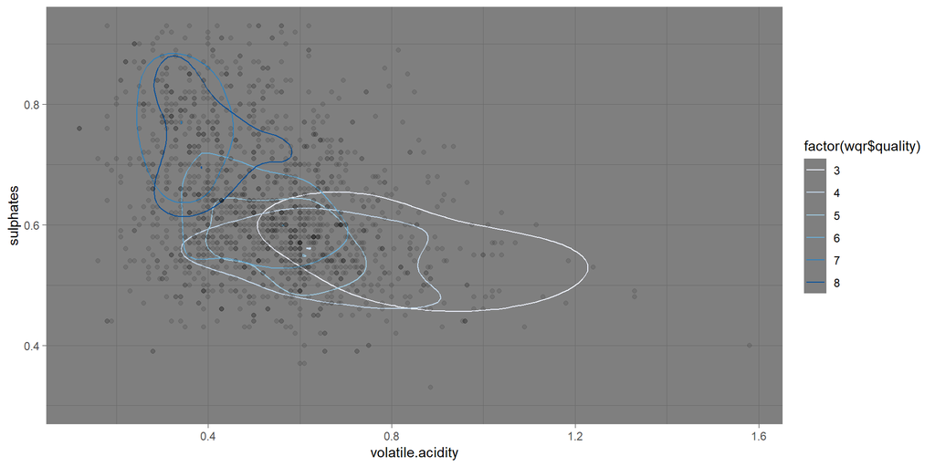

Now, we almost can tell the result before plotting. As of sulphates are positive correlated with quality, while volatile acidity is negative correlated with quality. So, the contour plot with the highest score of quality should show up with higher value of sulphates and lower value of volatile acidity. No wonder, the plot exactly shows the result what we are expecting.

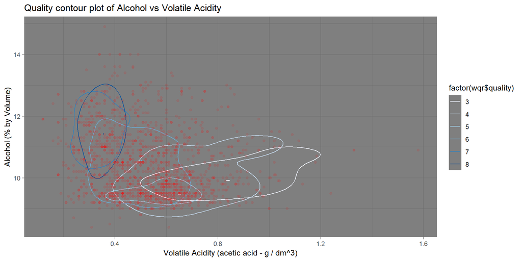

Letâs try to summarize quality using a contour plot of density and alcohol content:

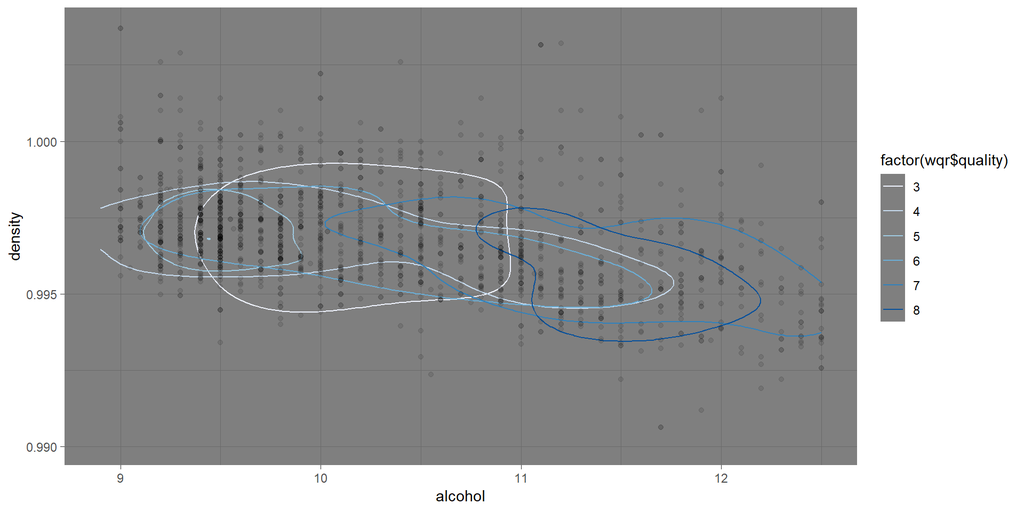

From above plot, we can tell that density does not really affact a lot of quality, but alcohol does.

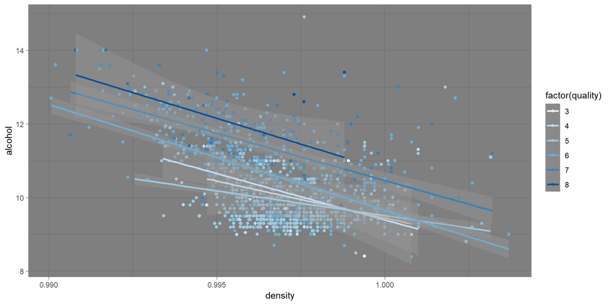

I am tring to use this plot to tell the same result with the previous one. However, the latest plot can tell more information within one plot.

# Multivariate Analysis

### Talk about some of the relationships you observed in this part of the investigation. Were there features that strengthened each other in terms of looking at your feature(s) of interest?

Based on the multivariate analysis, five features stood out to me: alcohol, sulphates, citric acid, volatile acidity, and quality. Volatile acidity with amount between 0.3 and 0.5 and sulphates with amount between 0.6 and 0.9 were a strong indicator of the presence of good wine. Also, high alcohol content and higher citric acid have more chance to make for a good wine.

observed relationship between quality of wine with different variables in the dataset, I found that amount of alcohol, volatile acidity, chlorides and total sulfur dioxide has great impact on deciding the perceived quality of wine.

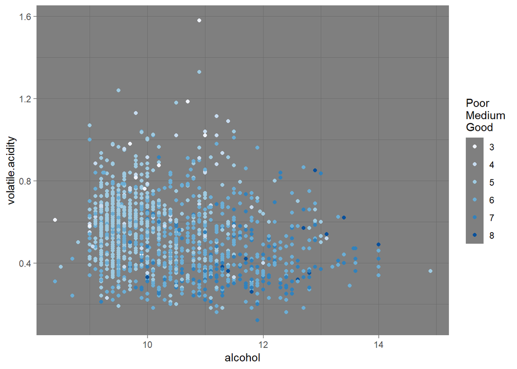

As we can see, most of the high quality rated wine observarations are those with higher alcohol and lower volatile acidity, while many of the mediocre to low quality rated wines are having lower alcohol and high volatile acidity. Some of the best quality of the wines are those with high alcohol and medium level of volatile acidity.

[output not shown]

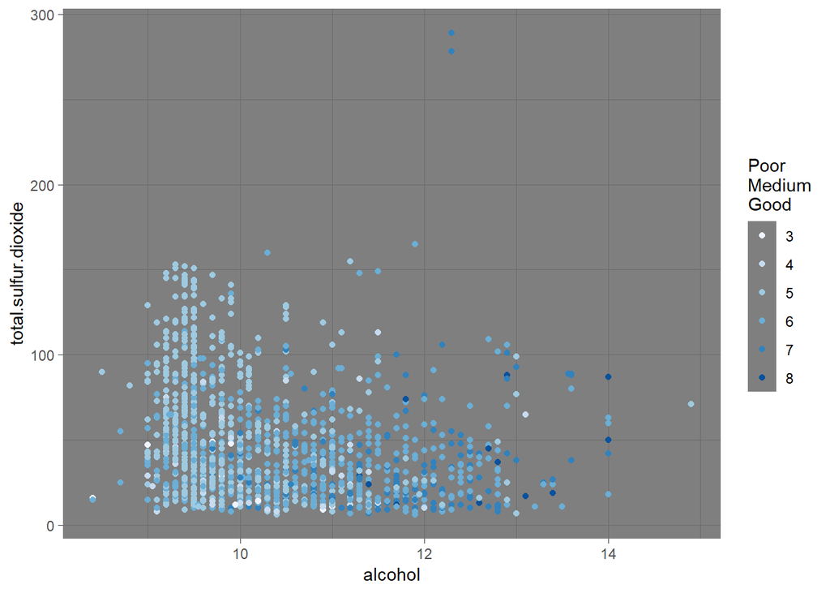

It’s visible that wines with relatively low total sulfur dioxide are getting higher qualtiy ratings. The wines with low alcohol are again getting lower quality rating.

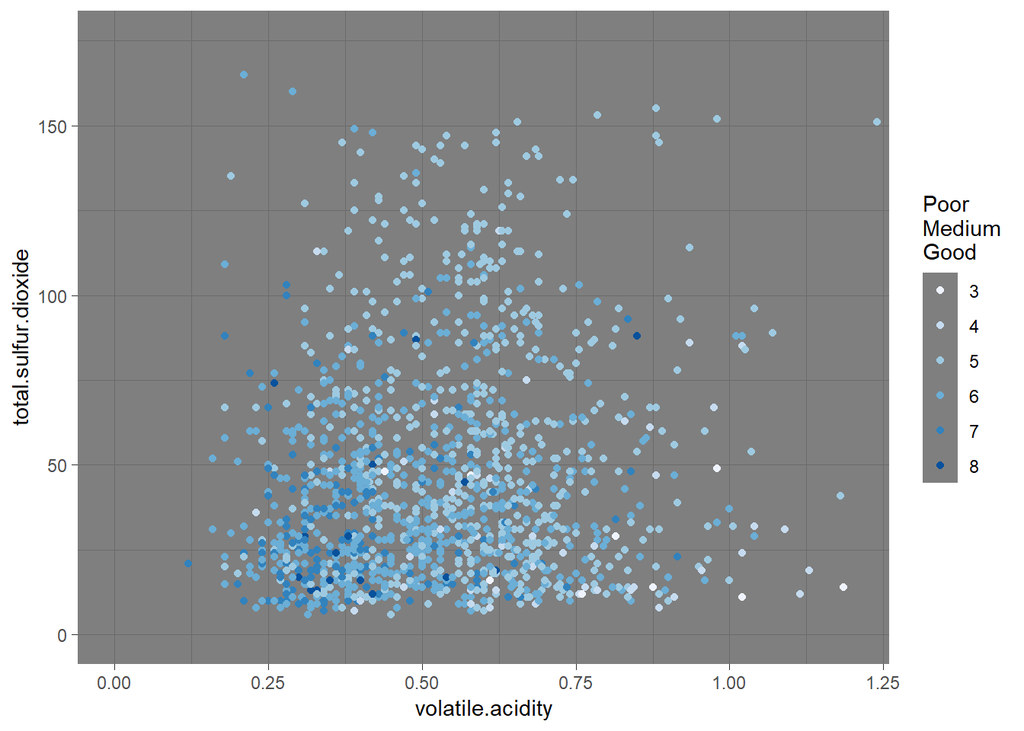

Most of the blue dots are concentrated in the lower left region. It’s clearly visible here that wines with low volatile acidity and low total sulfur dioxide have higher perceived quality than other samples.

Training a linear model with the dataset to predict the perceived quality of wine.

```
##
## Call:
## lm(formula = quality ~ alcohol + volatile.acidity + chlorides,
##     data = wqr)
##
## Coefficients:
##      (Intercept)           alcohol  volatile.acidity         chlorides
##           3.1574            0.3106           -1.3821           -0.3343
```

As the model suggests, the percentage of alcohol present in wine positively contributes to the quality of wine while volatile.acidity and chlorides contribute negatively to quality as evident by the coefficients. # Final Plots and Summary

### Plot One

As analyzing relationship between quality and other 11 attributes, the strongest correlation coefficient was found between alcohol and quality.

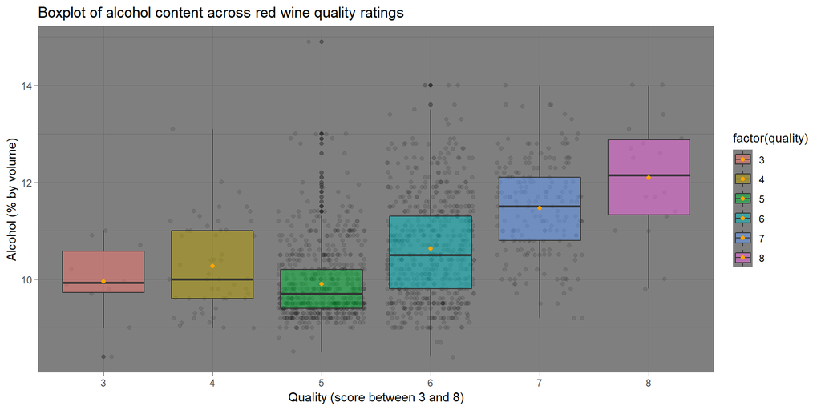

```
## # A tibble: 6 x 2
##   quality     n
##     <int> <int>
## 1       3    10
## 2       4    53
## 3       5   681
## 4       6   638
## 5       7   199
## 6       8    18
```

```
## wqr$quality: 3
##    Min. 1st Qu.  Median    Mean 3rd Qu.    Max.
##   8.400   9.725   9.925   9.955  10.575  11.000
## --------------------------------------------------------
## wqr$quality: 4
##    Min. 1st Qu.  Median    Mean 3rd Qu.    Max.
##    9.00    9.60   10.00   10.27   11.00   13.10
## --------------------------------------------------------
## wqr$quality: 5
##    Min. 1st Qu.  Median    Mean 3rd Qu.    Max.
##     8.5     9.4     9.7     9.9    10.2    14.9
## --------------------------------------------------------
## wqr$quality: 6
##    Min. 1st Qu.  Median    Mean 3rd Qu.    Max.
##    8.40    9.80   10.50   10.63   11.30   14.00
## --------------------------------------------------------
## wqr$quality: 7
##    Min. 1st Qu.  Median    Mean 3rd Qu.    Max.
##    9.20   10.80   11.50   11.47   12.10   14.00
## --------------------------------------------------------
## wqr$quality: 8
##    Min. 1st Qu.  Median    Mean 3rd Qu.    Max.
##    9.80   11.32   12.15   12.09   12.88   14.00
```

### Description One

Clearly we see that the box plots for higher quality red wines are up shifted, meaning they have a comparatively higher alcohol content, compared to the lower quality red wines.

### Plot Two

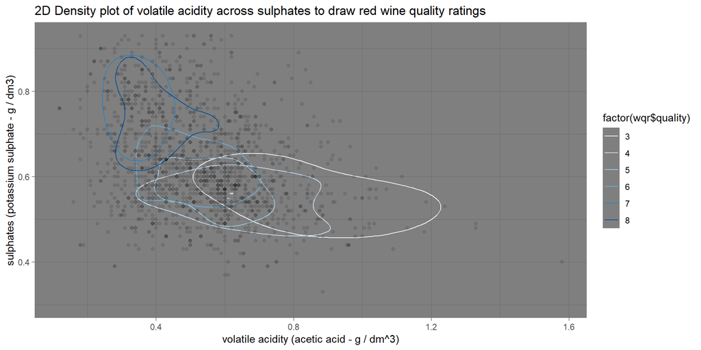

### Plot Three

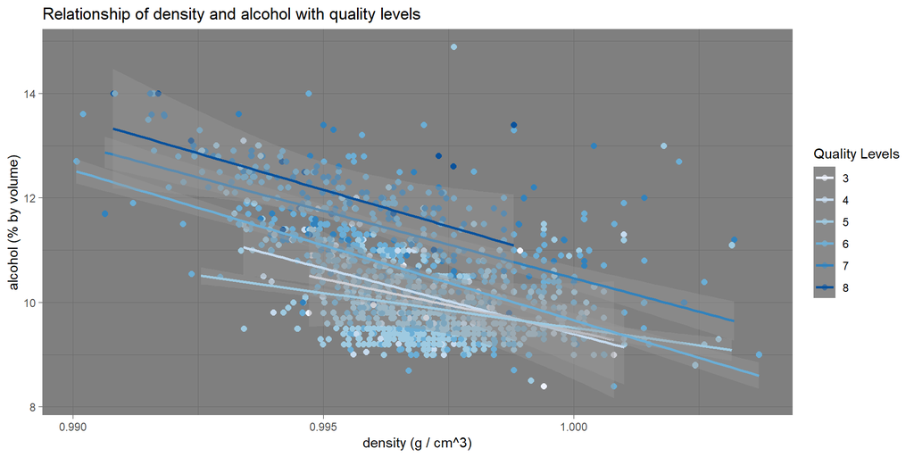

### Description Three

This shows that higher quality red wines are generally having higher percentage of alcohol, which is more than 11%, also having slightly lower density, which means the refreshing wine is somehow being more popular. With the help of density, actually, for the low quality levels with score of 3, 4 and 5, it is hard to tell how alcohol percentage affact the quality. Then, for the high levels of 6, 7 and 8, it is so obverious that more alcohol content would result a better wine quality.

# Reflection

I learned from this project was that I could understand through scatter plots, which of the various chemical properties of wine affect the perceived quality of wine.

I didn’t find any major difficulties while dealing with this data,I think pH level makes balance to provide good taste for wine. The red wine dataset contains information on 1,599 red wine instances, 11 attributes and one output attribute. Initially, I tried to get a sense of how is each attribute changing on their own. All univariate plots have been arranged together. Many of the variables look normally distributed. However, some of features have lognormal distributions. I exclude the 95th percentile for these features and re-plot their histograms.

Then, I tried to find what factors might affect the quality of the wine. At this moment, pearson correlation coefficient can help us to visualize the relationship between each pair of variables. Using the insights from correlation coefficients provided by the paired plots, it was interesting exploring quality using box plots with a different color for each quality. Besides, melting the dataframe and using facet grids was really helpful for visualizing the distribution of the parameters with the use of scatter plots. Finally, using a contour plot of wine quality with a point plot of volatile acidity and alcohol would be a good choice to show that either the lower volatile acidity or higher alcohol have more possible to make a better wine. The result makes sense. Volatile acidity is mostly caused by bacteria in the wine which is the amount of acetic acid in wine. It can lead to an unpleasant, vinegar taste if at too high of levels.

The hardest time for me is to understanding all the features with wiki pedia or other documents. But to be a good data analyst, we must study and understand the data structure as much as we can. Finally, I figured out all attributes of red wine.

The dataset may include more features of the environment where grapes are grown. As we all known, location and temperature play the important roles in the quality of wine.

# Citation

P. Cortez, A. Cerdeira, F. Almeida, T. Matos and J. Reis. Modeling wine preferences by data mining from physicochemical properties. In Decision Support Systems, Elsevier, 47(4):547-553. ISSN: 0167-9236.